# Homework 2

Scott Girten

September 25, 2019

## Problem 1

*The monthly values of the average hourly wages for U.S. apparel and textile workers for July 1981 to June 1987 are in the wages object in the TSA package. Type library(TSA); data(wages); You may want to type print(wages) in R to see the data set.*

### Part A

*Create a time series plot of the data and discuss any patterns you observe. Include your plot and your discussion.*

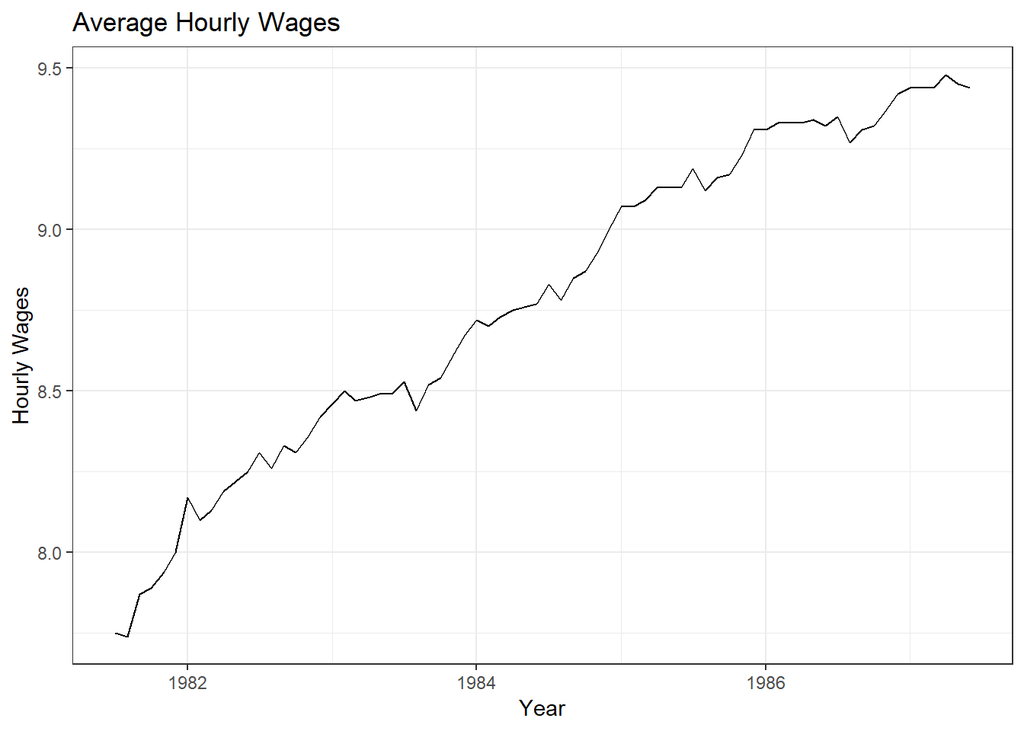

```r
library(TSA)
library(tidyverse)
library(ggfortify)
data(wages)

wage_plot = autoplot(wages) +
  ylab("Hourly Wages") +
  theme_bw() +
  ggtitle("Average Hourly Wages") +
  xlab("Year")
plot(wage_plot)
```

**Patterns:** The data shows a positively increasing trend over time. There seems to be a small spike in the middle of the year and the last half of the year sees a greater increase in wages relative to the first half of the year in which wages are either flat or up slightly.

### Part B

*Fit a quadratic trend for this data. You will need the time variable and a squared time variable. The following code is one way to create a time variable. Notice you could have a different “0” point, but this code sets 0 as January 1981. The linear model function can fit a quadratic trend using lm(wages~timewages+timewages2). Create a plot of the rstudent() residuals. Based on this plot, what do you think about the independence assumption of the values? Complete a runs test and write a conclusion (include the test statistic and p-value in your summary sentence).*

**Linear Model**

```r
timewages = 1:72
for (i in 1:72){
  timewages[i] = 0.5 + i / 12
}

timewages2 = timewages * timewages

wages_fit = lm(wages~timewages + timewages2)
wages_fit
```

```
##
## Call:
## lm(formula = wages ~ timewages + timewages2)
##
## Coefficients:
## (Intercept)    timewages   timewages2
##     7.58635      0.43289     -0.02143
```

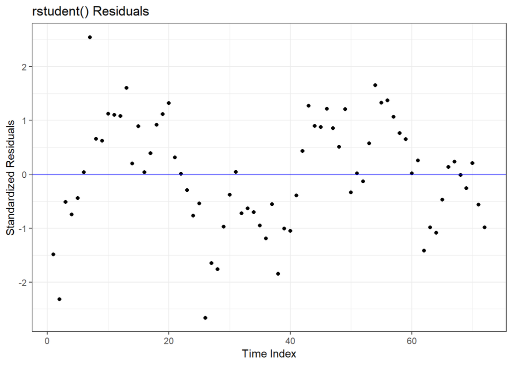

```r
resid = rstudent(wages_fit)

# Create index to make a data frame for plotting
index = c(1:72)
resid_tibble = tibble(index, resid)

# Residual plot of studentized residuals
resid_plot = ggplot(resid_tibble, aes(x = index, y = resid)) +
  geom_point() +
  theme_bw() +
  geom_hline(yintercept = 0, color = "blue") +
  ylab("Standardized Residuals") +
  xlab("Time Index") +
  ggtitle("rstudent() Residuals")
plot(resid_plot)
```

Based on the residual plot, it does not appear that data points are independent. The residuals do not have a random pattern, which implies that the data points are not independent.

**Runs Test**

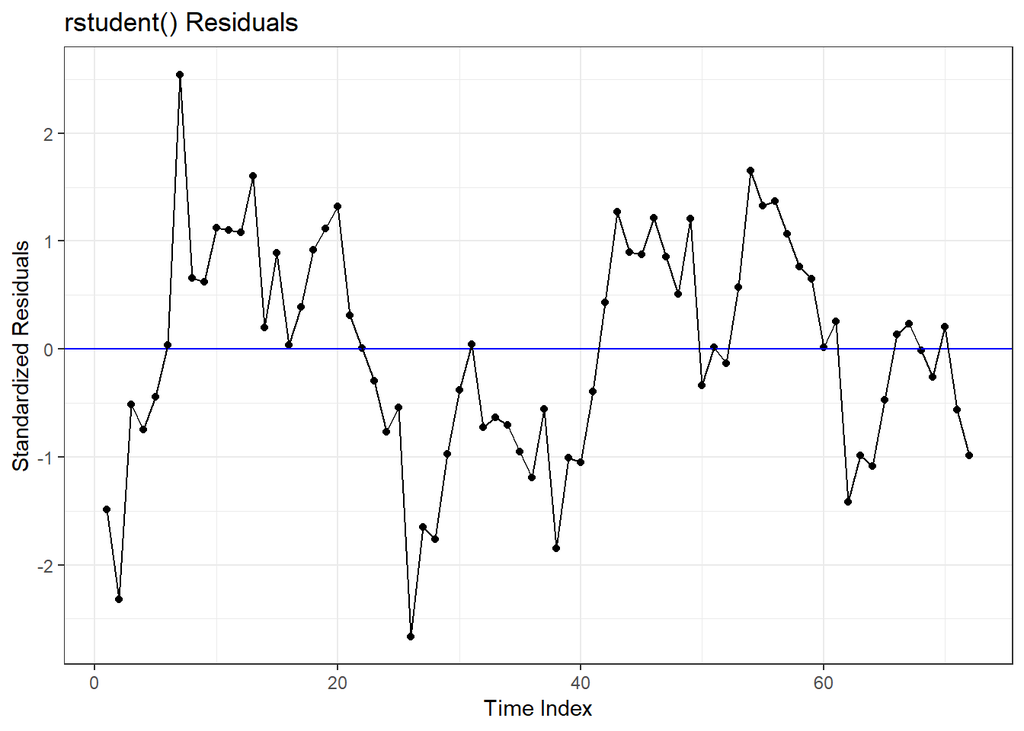

```r
# Runs plot of residuals
runs_plot = resid_plot +
  geom_line()
plot(runs_plot)
```

**Output of the runs function**

```r
runs_test = runs(resid)
runs_test
```

```
## $pvalue
## [1] 1.56e-07
##
## $observed.runs
## [1] 15
##
## $expected.runs
## [1] 36.75
##
## $n1
## [1] 33
##
## $n2
## [1] 39
##
## $k
## [1] 0
```

```r
# Calculate sigma^2 for the runs test
numerator = 2 * (runs_test$n1 * runs_test$n2) * (2 * (runs_test$n1 * runs_test$n2) - 72)
denominator = 72 * 72 * (72 - 1)

sigma_runs = numerator / denominator

runs_z_score = abs(runs_test$observed.runs - runs_test$expected.runs) / sigma_runs
```

*Create a histogram of the rstudent() residuals. What do you think about the normality assumption of the residuals? Complete a Shapiro-Wilks test and write a summary.*

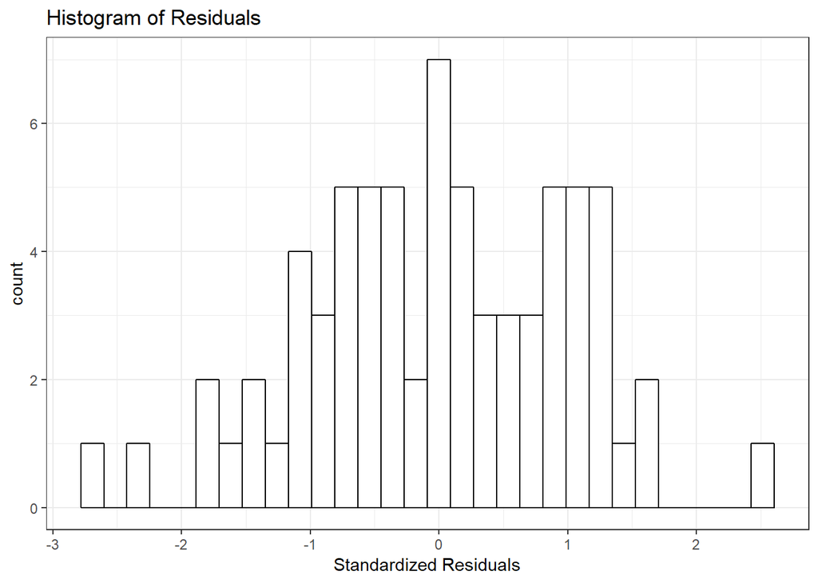

```r
resid_hist = ggplot(resid_tibble, aes(resid)) +
  geom_histogram(fill = "white", color = "black") +
  theme_bw() +
  xlab("Standardized Residuals") +
  ggtitle("Histogram of Residuals")
plot(resid_hist)
```

The histogram of the residuals does not provide evidence to contradict the assumption of normality. The histogram is symmetric and mounded in the center of the distribution, as you would expect with a normal distribution.

**Shapiro-Wilks Test**

```r
# Shapiro-Wilks normality test
shap_wilks_test = shapiro.test(resid)
shap_wilks_test
```

```
##
##  Shapiro-Wilk normality test
##
## data:  resid
## W = 0.98868, p-value = 0.7693
```

**W:** 0.9887

**p-value:** 0.7693

**Summary:** With a p-value of 0.7693 from the Shapiro-Wilks test, there is not sufficient evidence to conclude that the distribution of the residuals differs from a Normal distribution.

### Part C

*Based on the plot of the rstudent() residuals, what other trend do you suspect might be in the data that has not been included in the model?*

I assume that there is some type of cyclical pattern to the residuals. The pattern in the residuals appears to be cyclical due to the wave pattern in the residuals. The original time series plot did display a potential cyclical pattern for every year. The first half of the year tended to have a smaller increase in wages, with a sharp spike halfway through the year and then the increase in wages for the second half of the year rise at a faster rate than wages did for the first half of the year. Based on the plot of the residuals and the original time series plot, I would assume there is some type of periodic trend in the data.

## Problem 2

**Theta Terms:**

$\theta_1 = .7$

**Theoretical Values for $\rho_1$ to $\rho_5$**

```r
theta1 = .7
theta2 = .2
theta3 = .4
denominator = (1 + .7^2 + .4^2 + .2^2)

rho_1 = (-1*theta1 + theta1*theta2 + theta2*theta3) / denominator
rho_2 = (-1*theta2 + theta2*theta3) / denominator
rho_3 = (-1*theta3) / denominator
rho_4 = 0
rho_5 = 0
```

$\rho_1$ = -0.2840237

$\rho_2$ = -0.0710059

$\rho_3$ = -0.2366864

$\rho_4$ = 0

$\rho_5$ = 0

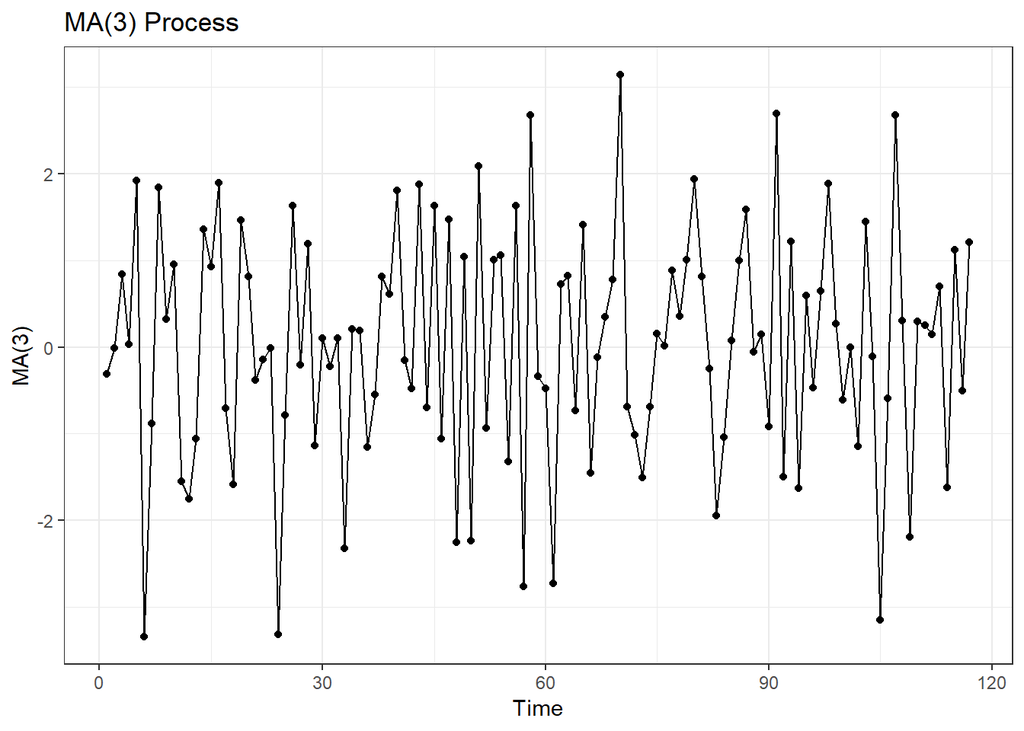

```r
# mean = 0 and standard deviation = 1
e120n = rnorm(120, 0, 1)

# Storage array for the ma3 process
yt_ma3 = 1:120
for (i in 1:120){
  yt_ma3[i] = (e120n[i+3] - theta1*e120n[i+2] - theta2*e120n[i+1] - theta3*e120n[i])
}

index = c(1:120)
ma3_data  = tibble(index, yt_ma3) %>%
  filter(!is.na(yt_ma3))

ma3_plot = ggplot(ma3_data, aes(x = index, y = yt_ma3)) +
  geom_point() +
  geom_line() +
  theme_bw() +
  xlab("Time") +
  ylab("MA(3)") +
  ggtitle("MA(3) Process")
plot(ma3_plot)
```

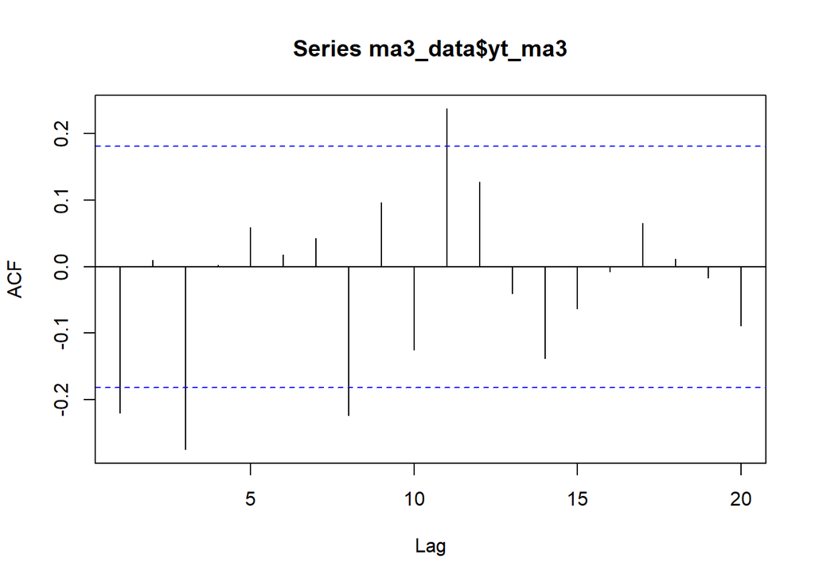

```r
acf_plot = acf(ma3_data$yt_ma3)
```